# Experiment 1: Demographics & Exclusions

Owen Morgan

June 25, 2024

### Recruitment & Exclusions

#### Everyone

| n (recruited) | n (with full task data) | exclusions | n (keepers) |
| --- | --- | --- | --- |
| 1,008 | 961 | 117 | 844 |

We have recruited 1008 participants through prolific. Of these, 961 completed the task phase of the experiment. 117 were excluded for the reasons described below, leaving 844 keepers.

How many subjects were excluded for multiple reasons?

| n_exclusion_reasons | n_subjects |
| --- | --- |
| 0 | 844 |
| 1 | 103 |
| 2 | 11 |
| 3 | 3 |

| n | Reason for exclusion |
| --- | --- |
| 117 | Any |
| 82 | Prescreener/EHI mismatch |
| 12 | Low accuracy (below 60% on any block) |
| 12 | Too many 'gos' (78/80 trials or more) |
| 11 | Reported having done the task before |
| 8 | Low RT (median < 200ms) |
| 5 | High RT (median > 1500ms) |
| 2 | Non-US country |
| 1 | Age outside 18-40 |
| 1 | Quit before completing EHI |

Participants were excluded if the handedness in their pre-screener strongly mismatched their EHI-measured handedness. These “Prescreener/EHI mismatch” exclusions have been defined as:

1. A Prolific “Left handed” participant with EHI >= 0
2. A Prolific “Ambidextrous” participant with EHI = +100 or -100
3. A Prolific “Right handed” participant with EHI <= 0

We could make these exclusions stricter by defining a mismatch as anything that doesn’t match the EHI bins we use in categorical analysis (left <= -40; mixed between -40 and 40; right >= +40). But I think this would be too conservative and would unnecessarily exclude many lefties and mixedies.

EHI distribution for each of Prolific’s prescreened handedness groups (all recruits with task data):

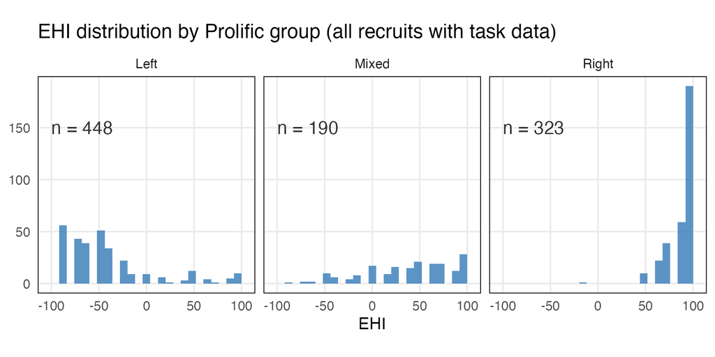

EHI distribution for each of Prolific’s prescreened handedness groups (mismatches excluded):

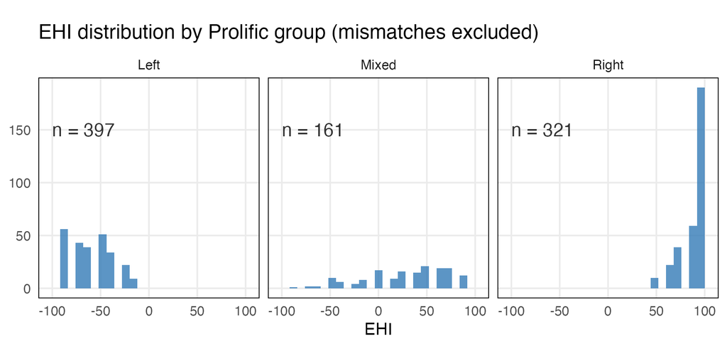

Prescreener/EHI mismatch exclusions (summary)

| Prolific handedness | EHI handedness<sup>1</sup> | n |
| --- | --- | --- |
| Left | Right | 32 |
| Left | Mixed | 19 |
| Mixed | Right | 28 |
| Mixed | Left | 1 |
| Right | Mixed | 1 |
| Right | Left | 1 |

<sup>1</sup> Left: (EHI <= -40) | Mixed: (-40 < EHI < 40) | Right: (EHI >= 40)

| Prolific handedness | EHI handedness<sup>1</sup> | n |
| --- | --- | --- |
| Left | Mixed | 65 |
| Left | Left | 332 |
| Mixed | Right | 71 |
| Mixed | Mixed | 75 |
| Mixed | Left | 15 |
| Right | Right | 320 |
| Right | - | 1 |

<sup>1</sup> Left: (EHI <= -40) | Mixed: (-40 < EHI < 40) | Right: (EHI >= 40)

#### By handedness group

| handedness | N | Age (years) | Education (years) | Sex (M/F/O) | EHI |
| --- | --- | --- | --- | --- | --- |
| Left | 349 | 28.83 (6.13) | 14.43 (2.41) | 179/166/4 | -81.59 (19.25) |
| Mixed | 160 | 28.74 (6.38) | 14.53 (2.56) | 93/65/2 | -6.8 (25.84) |
| Right | 451 | 29.18 (5.93) | 14.27 (2.5) | 232/212/7 | 86.11 (17.16) |
| - | 1 | - | - | 1/0 | - |

| prolific_handedness | n | ehi_mismatches |
| --- | --- | --- |
| Left | 448 | 51 |
| Mixed | 190 | 29 |
| Right | 323 | 2 |

How many subjects were excluded for multiple reasons?

| handedness | n_exclusion_reasons | n_subjects |
| --- | --- | --- |
| Left | 0 | 331 |
| Left | 1 | 13 |
| Left | 2 | 4 |
| Left | 3 | 1 |
| Mixed | 0 | 135 |
| Mixed | 1 | 22 |
| Mixed | 2 | 2 |
| Mixed | 3 | 1 |
| Right | 0 | 378 |
| Right | 1 | 67 |
| Right | 2 | 5 |
| Right | 3 | 1 |
| - | 1 | 1 |

| n (Right) | Reason for exclusion |
| --- | --- |
| 73 | Any |
| 60 | Prescreener/EHI mismatch |
| 5 | Low accuracy (below 60% on any block) |
| 5 | Reported having done the task before |
| 5 | Too many 'gos' (78/80 trials or more) |
| 2 | High RT (median > 1500ms) |
| 2 | Low RT (median < 200ms) |
| 1 | Non-US country |
| 0 | Age outside 18-40 |
| 0 | Quit before completing EHI |

| n (Mixed) | Reason for exclusion |
| --- | --- |
| 25 | Any |
| 20 | Prescreener/EHI mismatch |
| 3 | Low RT (median < 200ms) |
| 2 | Low accuracy (below 60% on any block) |
| 1 | Age outside 18-40 |
| 1 | High RT (median > 1500ms) |
| 1 | Reported having done the task before |
| 1 | Too many 'gos' (78/80 trials or more) |
| 0 | Non-US country |
| 0 | Quit before completing EHI |

| n (Left) | Reason for exclusion |
| --- | --- |
| 18 | Any |
| 6 | Too many 'gos' (78/80 trials or more) |
| 5 | Low accuracy (below 60% on any block) |
| 5 | Reported having done the task before |
| 3 | Low RT (median < 200ms) |
| 2 | High RT (median > 1500ms) |
| 2 | Prescreener/EHI mismatch |
| 1 | Non-US country |
| 0 | Age outside 18-40 |
| 0 | Quit before completing EHI |

### Demographics (Keepers)

#### By handedness group

Demographics for included participants, by handedness group (EHI bins).

| Handedness | N | Age (years) | Education (years) | Sex (M/F/O) | EHI |
| --- | --- | --- | --- | --- | --- |
| Left | 331 | 28.84 (6.1) | 14.45 (2.39) | 170/157/4 | -81.61 (19.27) |
| Mixed | 135 | 28.83 (6.17) | 14.58 (2.6) | 77/56/2 | -8.89 (26.49) |
| Right | 378 | 29.38 (5.93) | 14.24 (2.5) | 194/178/6 | 86.01 (16.61) |

Left: (EHI <= -40) | Mixed: (-40 < EHI < 40) | Right: (EHI >= 40)

Distribution within each EHI bin (keepers only):

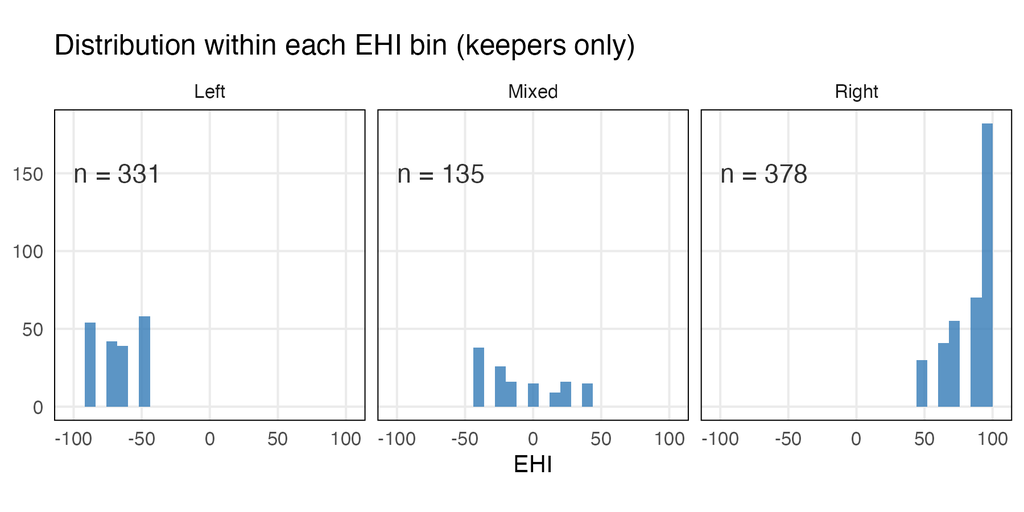

EHI distribution for each of Prolific’s prescreened handedness groups (keepers only):

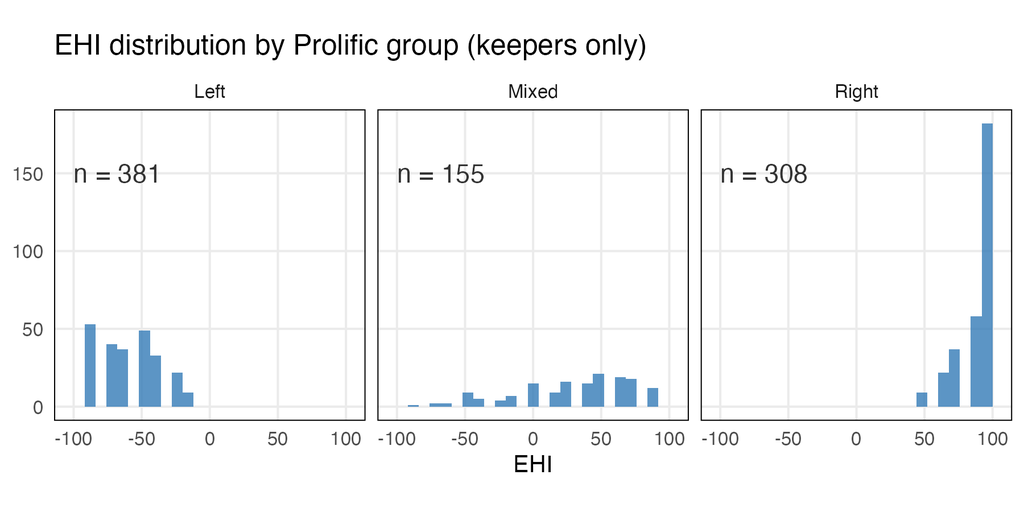

#### Everyone

Demographics for all included participants.

Demographics

Summary

| N | Age (years) | Education (years) | Sex (M/F/O) | EHI |
| --- | --- | --- | --- | --- |
| 844 | 29.08 (6.03) | 14.38 (2.48) | 441/391/12 | 5.09 (79.37) |

| Country | n |
| --- | --- |
| US | 844 |

| Race | n |
| --- | --- |
| White | 606 |
| Black or African American | 82 |
| Multiple | 76 |
| Asian | 69 |
| American Indian or Alaska Native | 5 |
| Native Hawaiian or Other Pacific Islander | 3 |
| Other | 3 |

| Hispanic ethnicity | n |
| --- | --- |
| No | 744 |
| Yes | 100 |

#### Group differences?

Any demographics differences between handedness groups?

Age (years)

| contrast | estimate | SE | df | lower.CL | upper.CL | t.ratio | p.value |
| --- | --- | --- | --- | --- | --- | --- | --- |
| Left - Mixed | 0.013 | 0.616 | 841 | −1.197 | 1.223 | 0.022 | 0.983 |
| Left - Right | −0.538 | 0.454 | 841 | −1.43 | 0.354 | −1.184 | 0.237 |
| Mixed - Right | −0.551 | 0.605 | 841 | −1.739 | 0.637 | −0.911 | 0.363 |

Education (years)

| contrast | estimate | SE | df | lower.CL | upper.CL | t.ratio | p.value |
| --- | --- | --- | --- | --- | --- | --- | --- |
| Left - Mixed | −0.129 | 0.253 | 838 | −0.626 | 0.369 | −0.509 | 0.611 |
| Left - Right | 0.211 | 0.187 | 838 | −0.155 | 0.577 | 1.132 | 0.258 |
| Mixed - Right | 0.34 | 0.249 | 838 | −0.149 | 0.829 | 1.366 | 0.172 |

Sex

| contrast | odds.ratio<sup>1</sup> | SE | df | asymp.LCL | asymp.UCL | null | z.ratio | p.value |
| --- | --- | --- | --- | --- | --- | --- | --- | --- |
| Left / Mixed | 0.787 | 0.163 | Inf | 0.524 | 1.183 | 1 | −1.151 | 0.25 |
| Left / Right | 0.993 | 0.151 | Inf | 0.738 | 1.338 | 1 | −0.043 | 0.966 |
| Mixed / Right | 1.262 | 0.257 | Inf | 0.846 | 1.882 | 1 | 1.139 | 0.255 |